# Lab Notebook

Grace Acton

# Welcome to my lab notebook!

In the interest of reproducible research, I have preserved all of my analyses in this lab notebook. That means it’s kind of messy! Code that does not work has been commented out, so this entire notebook should be able to be knit and viewed as an HTML document without issue.

# Research Question

**What histories are prioritized in National History Bowl questions? Which histories are excluded?**

## Project Data

Below is a data dictionary for the complete dataset, which is saved in the `data` folder as `nhbb_FULL_CLEAN.csv`.

```r
# use tidyverse packages for data cleaning
library(tidyverse)
# use reticulate package to access python
library(reticulate)

# use knitr and kableextra to create tables
library(knitr)
library(kableExtra)
data_dict <- read.csv("data/data_dict_nhbb.csv")
kable(data_dict) %>%
  kable_styling(latex_options = "striped",
                full_width = T) %>%
  column_spec(3, width = "3in")
```

| Variable | Type | Description | Acceptable.Values |
| --- | --- | --- | --- |
| ID | character | A unique identifier for each question block, generated from the year, set, tournament round, and lightning round numbers. |  |
| year | integer | The year the set was played in. | 4-digit year |
| set | integer | The difficulty level of the set. | c, a, nationals |
| tournament_round | integer | The round within a tournament that the set was played during. | 1, 2, 3, 4, 5 |
| game_round | integer | Round number within the game, sometimes called a “quarter”. | 1, 2, 3, 4 |
| lightning_round | integer | If the question was played in round 3, indicates which of the 3 possible lightning rounds the question was part of. | 1, 2, 3 |
| question_num | integer | Number of the question within its quarter. “Extra” indicates that the question was included at the end of the packet, only to be used in cases of a misread question or as a tiebreaker. | 1 - 10, extra |
| type | character | What format is the question? | tossup, tossup + bonus, or lightning |
| lightning_lead | character | The lead-in phrase for a lightning round. |  |
| q_text | character | Text of the question. |  |
| a_text | character | Answer to the question. |  |
| bonus_q_text | character | If question is of type “tossup + bonus”, this variable contains the text of the bonus question. |  |
| bonus_a_text | character | If question is of type “tossup + bonus”, this variable contains the text of the answer to the bonus question. |  |
| is_person_a | boolean | Is the answer to the question a person? | TRUE, FALSE |
| is_myth_a | boolean | Is the answer to the question a mythological or religious figure? | TRUE, FALSE |
| is_person_b | boolean | Is the answer to the bonus question a person? | TRUE, FALSE |
| is_myth_b | boolean | Is the answer to the bonus question a mythological or religious figure? | TRUE, FALSE |
| woman_named | boolean | Is a woman mentioned by name in the text of the question, answer, bonus question, or bonus answer? | TRUE, FALSE |
| is_fictional | boolean | Are any of the women named a fictional character? | TRUE, FALSE |
| is_myth | boolean | Are any of the women named a mythological or religious figure? | TRUE, FALSE |
| is_answer | boolean | Is a named woman the answer to the question? | TRUE, FALSE |
| names | character | Names of women mentioned in the question, separated by commas. |  |
| author | character | If included in the question set, name of the author for each question. |  |

# Data Import and Cleaning

Although there has already been an element of human oversight of the questions – namely, my reading the questions as I transcribed them in order to detect OCR errors and identify womens names – some formatting elements of National History Bowl questions are easier to remove or rectify in an automated fashion. Many questions contain pronunciation guides, which aren’t necessary to this analysis. Additionally, special characters are used in fourth quarter questions to identify the cut-off points between the 30-point, 20-point, and 10-point portions of the questions. As an exemplar of the complex formatting of a fourth quarter question, I provide Question 5 from Quarter 4 of Round 2 of the 2022 National Championship:

**This country resettled Jewish refugees from Nazi Germany in the town of Sosúa [[soh-SOO-ah]] after the Évian Conference. During one massacre in this country, the fate of the victims was determined by how they pronounced the term “perejil’’ [[peh-reh-HEEL]] (+) when soldiers held up a certain herb. One leader of this country had several thousands migrants from a neighboring country killed in the Parsley Massacre and was nicknamed”El (*)** Jefe” [[HE-feh]]. For ten points, name this Caribbean country that was ruled for over thirty years by Rafael Trujillo [[troo-HEE-yoh]] from Santo Domingo.

This question has special characters “(+)” and “(*)“, as well as double-bracketed pronunciation guides, all of which are superfluous to the text necessary for my analysis. The script `data_prep.R` uses the `stringr` package to remove these additional characters, leaving just the plaintext of the questions.

Additionally, the `data_prep.R` script uses metadata about the packets and questions to generate a unique identifier for each question and answer. This identifier is ispired by a standard museum object labeling format, which takes the form of `year.accession.box.object`. In this case, I have amended the format to be `year.set.tournament_round.quarter.question_number`. *Quarter 3 questions have an additional digit indicated which thematic lightning round option the question was part of.*

When questions and answers are written to text files, the ID number is followed by an underscore and an additional identifier: `_q` for question, `_a` for answer, `_bonus_q` for quarter 2 bonus questions, or `_bonus_a` for answers to quarter 2 bonus questions. Creating separate files for questions and answers allow them to be analyzed separately, and embedding these identifiers into the file names will allow me to easily separate questions from answers, while having a shared ID number maintains the connection between a question and its corresponding answer.

```r
# use data prep script as source

# if scripts aren't loading, make sure that the working directory is the project directory!

source("~/Desktop/hist426/scripts/data_prep.R") # change this to your correct local filepath

# the version of the data that is loaded in this script does not contain all of the necessary metadata
# the following code adds additional metadata to each question, and saves the end product as `nhbb_clean`

people_answers_tags <- read.csv("data/nhbb_added_metadata.csv") %>%
  select(ID, is_person_a, is_myth_a, is_person_b, is_myth_b) %>%
  replace(is.na(.), FALSE)

nhbb_clean <- left_join(nhbb_clean, people_answers_tags, by = c("ID")) %>%
  select(ID, year, set, tournament_round, game_round, lightning_round, question_num,
         type, lightning_lead, q_text, a_text, bonus_q_text, bonus_a_text, is_person_a,
         is_myth_a, is_person_b, is_myth_b, woman_named, is_fictional, is_myth, is_answer,
         names, author)
```

```r
# load write_txt function from its script
source("~/Desktop/hist426/scripts/write_txt.R") # change this to your correct local filepath
```

**To bypass the need to run the `data_prep.R` script, run the following code block, which loads the complete, cleaned dataset as `nhbb_clean`.**

```r
nhbb_clean <- read.csv("nhbb_FULL_CLEAN.csv")
```

# Quantifying Women’s Inclusion/Exclusion

### 1. For how many questions is the answer a woman?

First, we need to know the total number of questions in the corpus. This is not so simple as knowing the number of rows in the data frame, because bonus questions are included in the same row as the tossup they were written to complement. So, to get the total number of questions, I need to know the number of tossups and the number of bonuses, and add them together.

```r
num_bonus <- nrow(nhbb_clean %>% filter(bonus_q_text != "")) # number of bonuses
num_tossup <- nrow(nhbb_clean %>% filter(q_text != ""))

total_qs <- num_bonus + num_tossup
total_qs
```

```
## [1] 1774
```

Next I will count the number of rows which I’ve tagged as having a woman as the answer/

```r
woman_answers <- nhbb_clean %>%
  filter(is_answer == T)
nrow(woman_answers)
```

```
## [1] 44
```

The following block of code creates a dataframe consisting only of questions which have a woman as the answer.

```r
# filter nhbb_clean to only questions that have a woman as the answer
woman_answers <- nhbb_clean %>%
  filter(is_answer == T)

# establish a new df for writing these questions to

woman_qs <- as.data.frame(matrix(ncol = 4, nrow = nrow(woman_answers)))
colnames(woman_qs) <- c("ID", "question", "answer", "type")

# write only questions for which the woman is the answer to the new df
for (i in 1:nrow(woman_answers)){
  if(woman_answers$a_text[i] %in% woman_answers$names[i] == TRUE |
     woman_answers$names[i] %in% woman_answers$a_text[i] == TRUE |
     grepl(woman_answers$a_text[i], woman_answers$names[i]) == TRUE |
     grepl(woman_answers$names[i], woman_answers$a_text[i]) == TRUE) {
    woman_qs$ID[i] <- woman_answers$ID[i]
    woman_qs$question[i] <- woman_answers$q_text[i]
    woman_qs$answer[i] <- woman_answers$a_text[i]
    woman_qs$type[i] <- "tossup/lightning"
  } else if(woman_answers$bonus_a_text[i] %in% woman_answers$names[i] == TRUE |
            woman_answers$names[i] %in% woman_answers$bonus_a_text[i] == TRUE |
            grepl(woman_answers$bonus_a_text[i], woman_answers$names[i]) == TRUE |
            grepl(woman_answers$names[i], woman_answers$bonus_a_text[i]) == TRUE){
    woman_qs$ID[i] <- woman_answers$ID[i]
    woman_qs$question[i] <- woman_answers$bonus_q_text[i]
    woman_qs$answer[i] <- woman_answers$bonus_a_text[i]
    woman_qs$type[i] <- "bonus"
  }
}

# fix the "type" column and include lightning lead-ins to question text

for (j in 1:nrow(woman_qs)) {
  if(grepl("lightning", woman_qs$ID[j]) == TRUE){
    woman_qs$type[j] <- "lightning"
    woman_qs$question[j] <- paste(woman_answers$lightning_lead[j], woman_answers$q_text[j], sep = "")
  } else if(woman_qs$type[j] == "tossup/lightning" &
            grepl("lightning", woman_qs$ID[j]) == FALSE){
    woman_qs$type[j] <- "tossup"
  }
}

# print as kable table
kable(woman_qs) %>%
  kable_styling(full_width = T) %>%
  column_spec(1, width = "15%") %>%
  column_spec(2, width = "50%")
```

| ID | question | answer | type |
| --- | --- | --- | --- |
| 2014.c.1.3.lightning.1.7 | What person or god from ancient Greece…Was called the “tenth muse” for her accomplishments as a female poet on Lesbos? | Sappho | lightning |
| 2014.c.3.1.9 | This author fictionalized Vice-President Aaron Burr in her novel The Minister’s Wooing and depicted fugitives in the Great Dismal Swamp in Dred. She wrote a “key to” her major novel, which led Abraham… | Harriet Beecher Stowe | tossup |
| 2014.c.3.3.lightning.2.7 | In the 1990s, who or what was the…Five-member “girl group” whose song “Wannabe” led the British pop culture revival? | The Spice Girls | lightning |
| 2014.c.5.1.10 | This military leader was declared a martyr by Pope Callixtus III, a generation after this saint’s capture at Compiègne. Pierre Cauchon led the court which condemned her to be burned at the stake in 14… | Joan of Arc | tossup |
| 2014.c.5.2.8 | This goddess, who was born from the left eye of Izanagi, is worshipped at a “grand shrine” that is torn down and rebuilt every twenty years. She is believed to be the ancestor of the “tenno,” who sits… | Amaterasu | tossup |
| 2014.c.5.3.lightning.3.3 | The Spanish Armada was… Sent against what Queen of England? | Elizabeth I | lightning |
| 2015.a.2.2.3 | This person, who was hired after her critical response to the “Quiet Observer” column in the Pittsburgh Dispatch won admirers, once spent 10 days undercover at Blackwell’s Island in order to expose th… | Nellie Bly | tossup |
| 2015.a.4.1.4 | Phil Ochs’ song “Outside of a Small Circle of Friends” was inspired by this person’s fate. Social scientists have used this person’s story as an example of the diffusion of responsibility and the byst… | Kitty Genovese | tossup |
| 2015.a.4.2.8 | This woman aided Richard Harman, who was arrested for smuggling illegal Tyndale Bibles. This woman’s influence is credited with causing the downfall of Lord Chancellor Thomas Wolsey. Along with musici… | Anne Boleyn | tossup |
| 2015.a.5.2.8 | This person helped found the settlement of Portsmouth on the island of Aquidneck. This person was killed in a massacre by the Siwanoy tribe. This woman was accused of being an antinomian, and after he… | Anne Hutchinson | tossup |
| 2015.nationals.1.2.8 | During this ruler’s tenure, it became popular for women to wear purple or gray dresses to show that they were in “half-mourning.” The Kensington system, which educated this leader, was devised by John… | Queen Victoria | tossup |
| 2015.nationals.2.3.lightning.2.7 | The Qing Dynasty…Was ruled by which Dowager Empress who faced the Boxer Rebellion? | Dowager Empress Cixi | lightning |
| 2015.nationals.3.1.4 | A teenager named Marcus Sarjeant shot at this person while she was riding her horse. In 1992, this woman’s daughter, Anne, divorced Captain Mark Phillips, while her son, Andrew, separated from Sarah F… | Elizabeth II | tossup |
| 2015.nationals.4.1.6 | This non-Christian deity is Vasco da Gama’s main supernatural helper in the Portuguese epic, the Lusiads. In Ovid’s Metamorphoses, this deity begs Jupiter to turn the murdered Julius Caesar into a sta… | Venus | tossup |
| 2015.nationals.4.3.lightning.3.1 | World War II… is the setting of what Holocaust’s victim The Diary of a Young Girl? | Anne Frank | lightning |
| 2015.nationals.4.4.5 | This politician remarked: “This is not cojones . This is cowardice” after Cuban pilots shot down two planes flown by Brothers to the Rescue. This politician articulated the “three Ds of NATO” and spar… | Madeleine Albright | tossup |
| 2015.nationals.4.extra.1 | This woman came into conflict with a relative advised by Pothinus during an inheritance dispute. This woman had her sister Arsinoe killed at the Temple of Artemis, and she supposedly drank a pearl dis… | Cleopatra | tossup |
| 2015.nationals.5.1.4 | The Trinovantes were recruited by this person to help battle an army led by Petillius Cerialis. This leader destroyed the city of Camulodunum before being defeated by Gaius Suetonius Paulinus. The lea… | Boudicca | tossup |
| 2015.nationals.5.2.8 | The winner of the 2012 Arthur Ashe Courage Award, this coach was named the Naismith Coach of the Century in 2000. Candace Parker made a landmark slam dunk while playing for this coach, who was diagnos… | Pat Summitt | tossup |
| 2015.nationals.5.4.5 | One ruler of this name was replaced by Amadeo I after abdicating. A ruler of this name abdicated after losing the Battle of Alcolea to Juan Prim and Francisco Serrano. That ruler succeeded her father … | Isabella | tossup |
| 2015.nationals.5.4.6 | This leader’s police opened fire on protesters at the Turkman Gate in an incident investigated by the Shah Commission. Slogans such as “Elect a Government That Works” and “Eradicate Poverty!” were use… | Indira Gandhi | tossup |
| 2021.c.1.1.1 | This woman employed the Munshi Abdul Karim as an Urdu teacher, and she described her grandson, William, as possessing “little heart and tact.” This person was advised in her early rule by Lord Melbour… | Queen Victoria | tossup |
| 2021.c.2.1.2 | This leader obtained a doctorate in quantum chemistry in 1986 prior to entering politics. This politician played a central role in negotiating the Treaty of Lisbon and was a main figure behind the sti… | Angela Merkel | tossup |
| 2021.c.2.1.5 | This ruler called Foreign Minister Nikita Panin a “personal encyclopedia,” though Panin fell out of favor by advocating for the Northern Alliance with Prussia. To convince this empress that the typica… | Catherine the Great | tossup |
| 2021.c.2.2.2 | This woman became Henry’s second wife after he secured his divorce from Catherine. This woman was the mother of future Queen Elizabeth I. | Anne Boleyn | bonus |
| 2021.c.2.2.7 | Immediately after the firing of Hue Jackson, the Cleveland Browns made overtures suggesting they would attempt to hire this female Secretary of State under the George W. Bush administration as their h… | Condoleeza Rice | bonus |
| 2021.c.3.1.3 | This woman’s actions at Werowocomoco are detailed in a letter to Queen Anne of Denmark. This womandied after travelling to England with her husband, John Rolfe, ten years after she intervened in an ex… | Pocahontas | tossup |
| 2021.c.3.1.8 | This politician openly criticized fellow party member Joe Manchin for using the term “young lady” while refuting her claims on his lack of transparency in negotiating with oil lobbyists. This congress… | Alexandria Ocasio-Cortez | tossup |
| 2021.c.3.2.7 | Another Titan, Mnemosyne , embodied memory and was the mother of what group of nine goddesses who inspired the humanities and sciences? | Muses | bonus |
| 2021.c.4.2.5 | Often incorporating aspects of the cult of Serapis , this deity names a “Mystery” practiced in the Greco-Roman world which guaranteed practitioners a place in the Fortunate Isles. An aspect of this go… | Isis | tossup |
| 2021.c.5.3.lightning.1.3 | Concerning U.S. domestic affairs during World War Two, name the… Propaganda symbol of U.S. women in the work force now used in feminist iconography. | Rosie the Riveter | lightning |
| 2021.c.5.4.1 | This deity was worshipped in Sparta under an epithet that translates to “Willow-Bound.” This deity, dubbed “of the Golden Shaft” was a patron of childbirth despite her personal chastity. Though this g… | Artemis | tossup |
| 2021.a.3.2.3 | The Uralic city of Yekaterinburg was the site of the execution of Tsar Nicholas II and his entire family, including which daughter of his who was rumored to have escaped, leading to imposters like Ann… | Anastasia Romanov | bonus |
| 2021.a.4.2.1 | Clinton nominated two Supreme Court justices, Stephen Breyer, and this late justice who died in September 2020. | Ruth Bader Ginsberg | bonus |
| 2021.a.4.2.6 | The city of Babylon contained an ancient “Gate” dedicated to which Mesopotamian goddess of love who attempts to woo Gilgamesh in an ancient epic? | Ishtar | bonus |
| 2021.a.4.3.lightning.1.8 | Concerning the Alamo, name the… Tennessee woman who, with her daughter Angelina, were the only two Anglo-Americans to survive the Alamo disaster. | Susanna Dickinson | lightning |
| 2021.a.5.4.4 | A ruler of this name presided over the “moderate decade” and the “progressive biennium,” both named for the party in power. One ruler of this name ordered the execution of her court rival Hugh le Desp… | Isabella I | tossup |
| 2022.nationals.1.1.10 | Sarah Hopkins Bradford wrote two biographies of this woman, including Scenes From the Life of . This woman led the forces of James Montgomery in the Raid on the Combahee Ferry during the U.S. Civil Wa… | Harriet Tubman | tossup |
| 2022.nationals.1.4.1 | This scientist worked under John Randall’s biophysics unit while on a threeyear Turner & Newall Fellowship at King’s College London. An article titled “The Structure of Viruses as Determined by X-Ray … | Rosalind Franklin | tossup |
| 2022.nationals.3.1.5 | This activist traveled with Henry Morgenthau Jr.’s wife to the Westmoreland Homesteads in Pennsylvania, after which residents renamed the area after the last syllables of her name. 165 homes for unemp… | Eleanor Roosevelt | tossup |
| 2022.nationals.4.2.4 | This woman and six of her children were killed by members of the Siwanoy tribe during Kieft’s War. Governor Henry Vane often attended meetings hosted by this woman, who eventually settled on Aquidneck… | Anne Hutchinson | tossup |
| 2022.nationals.4.4.4 | The sacred fire in this non-Greek deity’s temple was extinguished by Theodosius I in 394 AD. In a festival celebrating this deity, a donkey was dressed in a garland of flowers as it was believed that … | Vesta | tossup |
| 2022.nationals.5.1.6 | In April 2021, this person promulgated support for a global minimum corporate tax rate. This economist postulated that paying workers more than their market value in wages increases productivity in th… | Janet Yellen | tossup |
| 2022.nationals.5.3.lightning.1.5 | Concerning the Second Red Scare, name the… Couple executed for spying on the U.S., sending nuclear weapon designs to the Soviets. | Julius and Ethel Rosenberg | lightning |

### 2. How many questions mention a woman by name?

To answer this question, I can again use my metadata tags and the `dplyr::filter()` function.

```r
woman_named <- nhbb_clean %>%
  filter(woman_named == T)

# number of questions that contain a named woman
nrow(woman_named)
```

```
## [1] 207
```

However, some of these may be questions for which the *answer* is a woman, but not mention a woman by name in the question text. It would be more accurate to filter out those questions which have a woman as the answer, and only add them back in if they contain another woman’s name.

```r
# establish a new df for writing these questions to

woman_named_df <- as.data.frame(matrix(ncol = 4, nrow = nrow(nhbb_clean)))
colnames(woman_named_df) <- c("ID", "names", "answer", "type")

# write questions to this new df
nhbb_clean <- nhbb_clean %>%
  filter(is.na(woman_named) == FALSE)

for (i in 1:nrow(nhbb_clean)) {
  if(nhbb_clean$woman_named[i] == TRUE & nhbb_clean$is_answer[i] == FALSE){
      woman_named_df$ID[i] <- nhbb_clean$ID[i]
      woman_named_df$names[i] <- nhbb_clean$names[i]
      woman_named_df$answer[i] <- nhbb_clean$a_text[i]
      woman_named_df$type[i] <- nhbb_clean$type[i]
  } else if(nhbb_clean$woman_named[i] == TRUE & nhbb_clean$is_answer[i] == TRUE) {
      names_vec <- as.list(strsplit(nhbb_clean$names[i], ", ")[[1]])
      if(length(names_vec) > 1) {
        woman_named_df$ID[i] <- nhbb_clean$ID[i]
        woman_named_df$names[i] <- nhbb_clean$names[i]
        woman_named_df$answer[i] <- nhbb_clean$a_text[i]
        woman_named_df$type[i] <- nhbb_clean$type[i]
      }
    }
}

woman_named_df <- woman_named_df %>%
  filter(is.na(names) == FALSE) %>%
  filter(names != answer)
```

So, of those 1774 total questions, 10.03 percent mention a woman by name.

### 3. Has the proportion of questions and answers that mention women changed over time?

Let’s get the IDs of questions that name a woman or have a woman answer, and use them to filter the original NHBB data.

```r
woman_ids <- unique(c(woman_answers$ID, woman_named_df$ID))

nhbb_women <- nhbb_clean %>%
  filter(ID %in% woman_ids) %>%
  mutate(q_or_a = if_else(is_answer == TRUE, "answer", "question"))
```

```r
women_year <- nhbb_women %>%
  group_by(year) %>%
  count(name = "women")

total_year <- nhbb_clean %>%
  group_by(year) %>%
  count(name = "total")

years <- left_join(women_year, total_year, by = "year")
years <- years %>%
  mutate(proportion = round(women/total, digits = 4))

years
```

| year | women | total | proportion |
| --- | --- | --- | --- |
| 2014 | 30 | 255 | 0.1176 |
| 2015 | 77 | 494 | 0.1559 |
| 2021 | 65 | 509 | 0.1277 |
| 2022 | 36 | 255 | 0.1412 |

Using a Chi-Squared test will let me see if the proportion of questions that feature women is likely to be related to the year the questions were written.

```r
# variables: year and proportion
# null hypothesis: the proportion of questions that feature women is unrelated to the year the set was written

chisq_data <- as.data.frame(years)
rownames(chisq_data) <- chisq_data$year
chisq_data <- chisq_data %>%
  select(-proportion) %>%
  mutate(no_women = total-women) %>%
  select(-total, -year)


chisq <- chisq.test(chisq_data)
chisq
```

```
##
##  Pearson's Chi-squared test
##
## data:  chisq_data
## X-squared = 2.6948, df = 3, p-value = 0.4411
```

```r
chisq$observed
```

```
##      women no_women
## 2014    30      225
## 2015    77      417
## 2021    65      444
## 2022    36      219
```

```r
chisq$expected
```

```
##         women no_women
## 2014 35.05618 219.9438
## 2015 67.91276 426.0872
## 2021 69.97488 439.0251
## 2022 35.05618 219.9438
```

### 4. Is the proportion of questions about women related to the difficulty level of the set?

This is the same sort of analytical approach I applied to the years. I’ll once again conduct a chi-squared test to see if these two variables are independent of each other.

```r
women_set <- nhbb_women %>%
  group_by(set) %>%
  count(name = "women")

total_set <- nhbb_clean %>%
  group_by(set) %>%
  count(name = "total")

sets <- left_join(women_set, total_set, by = "set")
sets <- sets %>%
  mutate(proportion = round(women/total, digits = 4))

sets
```

| set | women | total | proportion |
| --- | --- | --- | --- |
| a | 67 | 504 | 0.1329 |
| c | 62 | 510 | 0.1216 |
| nationals | 79 | 499 | 0.1583 |

```r
# variables: year and proportion
# null hypothesis: the proportion of questions that feature women is unrelated to the year the set was written

chisq_data <- as.data.frame(sets)
rownames(chisq_data) <- chisq_data$set
chisq_data <- chisq_data %>%
  select(-proportion) %>%
  mutate(no_women = total-women) %>%
  select(-total, -set)


chisq <- chisq.test(chisq_data)
chisq
```

```
##
##  Pearson's Chi-squared test
##
## data:  chisq_data
## X-squared = 3.0037, df = 2, p-value = 0.2227
```

```r
chisq$observed
```

```
##           women no_women
## a            67      437
## c            62      448
## nationals    79      420
```

```r
chisq$expected
```

```
##              women no_women
## a         69.28751 434.7125
## c         70.11236 439.8876
## nationals 68.60013 430.3999
```

Once again, these two variables are likely not related.

# Using `reticulate` to access SpaCy

The R package `reticulate` lets me run Python code blocks in this same notebook!

Let’s use `SpaCy` to find proper nouns and toponyms in the dataset.

```r
library(reticulate)

use_condaenv("native") # full path: /opt/anaconda3/envs/native/bin/python
# if having issues, run reticulate::py_config() --> all lines should be referring to the virtual environment
# if one of the reticulate::py_config() lines isn't correct, restart R and try again
```

```python
import spacy

# import pandas DataFrame packages
import pandas as pd
```

```python
nhbb_spacy=pd.read_csv("data/nhbb_clean.csv")
nlp = spacy.load("en_core_web_sm")
```

```python
# tokenize questions
  # define function to use nlp function on texts
def process_text(text):
  return nlp(text)
  # define function to return list of tokens for each text
def get_token(doc):
  return [(token.text) for token in doc]
  # define function to get part of speech for each token
def get_pos(doc):
  return [(token.pos_, token.tag_) for token in doc]
```

```python
nhbb_spacy['q_text_doc'] = nhbb_spacy['q_text'].apply(process_text)
nhbb_spacy['q_text_tokens'] = nhbb_spacy['q_text_doc'].apply(get_token)
nhbb_spacy['q_text_pos'] = nhbb_spacy['q_text_doc'].apply(get_pos)
```

### Extracting Proper Nouns

```python
# Return only proper nouns
def extract_prop_nouns(doc):
  return [token.text for token in doc if token.pos_ == 'PROPN']

nhbb_spacy['prop_nouns'] = nhbb_spacy['q_text_doc'].apply(extract_prop_nouns)
```

```r
nhbb_spacyr <- py_to_r(py$nhbb_spacy)
prop_nouns <- nhbb_spacyr %>%
  mutate(prop_nouns = as.character(prop_nouns)) %>%
  filter(prop_nouns != "list()")

# count instances of each proper noun
for (i in 1:nrow(prop_nouns)){
  prop_nouns$prop_nouns[i] <- str_remove_all(prop_nouns$prop_nouns[i], pattern = "c\\(")
  prop_nouns$prop_nouns[i] <- str_remove_all(prop_nouns$prop_nouns[i], pattern = "\\)")
  prop_nouns$prop_nouns[i] <- str_remove_all(prop_nouns$prop_nouns[i], pattern = "\"")
  prop_nouns$prop_nouns[i] <- str_remove_all(prop_nouns$prop_nouns[i], pattern = " ")
}

prop_nouns_count <- prop_nouns %>%
  separate_longer_delim(cols = prop_nouns, delim = ",") %>%
  group_by(prop_nouns) %>%
  count() %>%
  arrange(desc(n))

head(prop_nouns_count)
```

| prop_nouns | n |
| --- | --- |
| War | 137 |
| U.S. | 106 |
| Battle | 96 |
| John | 72 |
| New | 72 |
| William | 62 |

```python
# Get Named Entity labels and assign to variable "labels"
labels = nlp.get_pipe("ner").labels

# Print labels and their descriptions
for label in labels:
  print(label + " : " + spacy.explain(label))
```

```
## CARDINAL : Numerals that do not fall under another type
## DATE : Absolute or relative dates or periods
## EVENT : Named hurricanes, battles, wars, sports events, etc.
## FAC : Buildings, airports, highways, bridges, etc.
## GPE : Countries, cities, states
## LANGUAGE : Any named language
## LAW : Named documents made into laws.
## LOC : Non-GPE locations, mountain ranges, bodies of water
## MONEY : Monetary values, including unit
## NORP : Nationalities or religious or political groups
## ORDINAL : "first", "second", etc.
## ORG : Companies, agencies, institutions, etc.
## PERCENT : Percentage, including "%"
## PERSON : People, including fictional
## PRODUCT : Objects, vehicles, foods, etc. (not services)
## QUANTITY : Measurements, as of weight or distance
## TIME : Times smaller than a day
## WORK_OF_ART : Titles of books, songs, etc.
```

```python
# define function to extract named entity *types* from doc objects
def extract_ne_tags(doc):
  return [ent.label_ for ent in doc.ents]

# Apply function to q_text_doc column and store named entity tags in new column
nhbb_spacy["ne_tags"] = nhbb_spacy["q_text_doc"].apply(extract_ne_tags)
```

```python
# define function to extract text tagged with named entities from from doc objects
def extract_named_entities(doc):
  return[ent.text for ent in doc.ents]

# Apply function to q_text_doc column and store named entities in new column
nhbb_spacy["named_entities"] = nhbb_spacy["q_text_doc"].apply(extract_named_entities)
```

```r
nhbb_spacyr <- py_to_r(py$nhbb_spacy)
named_entities <- nhbb_spacyr %>%
  mutate(named_entities = as.character(named_entities)) %>%
  filter(named_entities != "list()")

# count instances of each proper noun
for (i in 1:nrow(named_entities)){
  named_entities$named_entities[i] <- str_remove_all(named_entities$named_entities[i], pattern = "c\\(")
  named_entities$named_entities[i] <- str_remove_all(named_entities$named_entities[i], pattern = "\\)")
  named_entities$named_entities[i] <- str_remove_all(named_entities$named_entities[i], pattern = "\"")
  named_entities$named_entities[i] <- str_trim(named_entities$named_entities[i])
  named_entities$named_entities[i] <- str_squish(named_entities$named_entities[i])
}


named_entities_count <- named_entities %>%
  separate_longer_delim(cols = named_entities, delim = ", ") %>%
  group_by(named_entities) %>%
  count() %>%
  arrange(desc(n))

head(named_entities_count)
```

| named_entities | n |
| --- | --- |
| ten | 404 |
| 10 | 387 |
| first | 155 |
| one | 95 |
| U.S. | 86 |
| British | 60 |

### Extract only place names

```python
# Define function to extract words tagged as "GPE", "LOC", or "FAC"
def extract_places(doc):
  return[ent.text for ent in doc.ents if ent.label_ == "GPE" or ent.label == "LOC" or ent.label == "FAC"]

# Apply function to nhbb_spacy DF column "q_text_doc" and save in new column
nhbb_spacy["places"] = nhbb_spacy["q_text_doc"].apply(extract_places)
```

```r
nhbb_spacyr <- py_to_r(py$nhbb_spacy)
places <- nhbb_spacyr %>%
  mutate(places = as.character(places)) %>%
  filter(places != "list()")

# count instances of each proper noun
for (i in 1:nrow(places)){
  places$places[i] <- str_remove_all(places$places[i], pattern = "c\\(")
  places$places[i] <- str_remove_all(places$places[i], pattern = "\\)")
  places$places[i] <- str_remove_all(places$places[i], pattern = "\"")
}

places_count <- places %>%
  separate_longer_delim(cols = places, delim = ", ") %>%
  group_by(places) %>%
  count() %>%
  arrange(desc(n))

head(places_count)
```

| places | n |
| --- | --- |
| U.S. | 86 |
| the United States | 29 |
| England | 24 |
| France | 24 |
| Spain | 21 |
| India | 16 |

# Mapping

I’ve commented these out because of how much time and RAM they take to run. If you want to run them, you’ll need to un-comment the blocks.

```r
library(leaflet)
library(tidygeocoder)
library(basemaps)
```

```r
# nhbb_places <- places %>%
#   select(ID, places) %>%
#   separate_longer_delim(cols = places, delim = ", ") %>%
#   geocode(places, method = "osm", lat = lattitude, long = longitude)
```

```r
# nhbb_geo <- read.csv("nhbb_places_geocoded.csv")
# nhbb_geo <- nhbb_geo %>%
#   select(-ID, -X)
#
# nhbb_places_counts <- left_join(x = places_count, y = nhbb_geo, by = c("places"))
#
# nhbb_places_counts <- nhbb_places_counts %>%
#   distinct()
#
# nhbb_places_counts$lattitude[1:2] <- 39.833
# nhbb_places_counts$longitude[1:2] <- -98.583
#
# map <- leaflet() %>%
#   addProviderTiles("Stadia.StamenTonerLite") %>%
#   addCircleMarkers(data = nhbb_places_counts,
#              lng = ~longitude,
#              lat = ~lattitude,
#              popup = ~places,
#              radius = ~n)
```

```r
# library(maps)
#
# world <- map_data("world")
#
# ggplot() +
#   geom_polygon(data = world, aes(long, lat, group = group),
#                color = "black",
#                fill = "lightgray") +
#   geom_point(data = nhbb_places, aes(longitude, lattitude,
#                               color = "red"))
```

This approach had a **huge** number of geocoding mistakes – “DC” and “Armenia” have both ended up in Colombia… the magnitude and quantity of errors makes the geocoded data unusable for analysis. I’m glad I tried this approach, but also happy to comment it out. :)

# Using OpenRefine to reconcile place names

I used OpenRefine’s data reconcilliation capability to reconcile place names identified by SpaCy against the Getty Thesaurus of Geographic Names. The hierarchical structure of the Getty TGN let me identify places at the country and continent level, which lets me analyze the geographical spread of the questions more reliably than geocoding individual points. This first round of analysis is only with one toponym per question, I will be going back to OpenRefine to reconcile the remaining toponyms later.

First, I want to look at what questions are **mentioned in the questions themselves**. In this analysis, I count places categorized by Getty as “primary political entities” and “former primary political entities”.

```r
nhbb_countries_qs <- read.csv("data/NHBB_countries_2.csv")

country_counts_qs <- nhbb_countries_qs %>%
  group_by(q_place_1) %>%
  count() %>%
  arrange(desc(n))

head(country_counts_qs)
```

| q_place_1 | n |
| --- | --- |
| United States | 86 |
| China | 16 |
| France | 15 |
| Germany | 12 |
| Japan | 11 |
| Soviet Union | 11 |

Now, I want to look at the countries that **contain the more specific entities mentioned in questions.** I will again use the same Getty place categories, but this time with the container countries.

```r
country_containers <- read.csv("data/nhbb_container_countries.csv")

country_counts_containers <- country_containers %>%
  group_by(parent_hierarchy1) %>%
  count() %>%
  arrange(desc(n))

head(country_counts_containers)
```

| parent_hierarchy1 | n |
| --- | --- |
| United States | 164 |
| United Kingdom | 44 |
| China | 18 |
| Greece | 15 |
| Israel | 12 |
| Italy | 12 |

Because the parent hierarchy for a country won’t also contain that country, I can add these to get the total number of instances of each country appearing in a question.

```r
all_countries <- full_join(country_counts_qs, country_counts_containers, by = c("q_place_1" = "parent_hierarchy1")) %>%
  replace(is.na(.), 0) %>%
  mutate(n.total = rowSums(across(where(is.numeric)))) %>%
  select(q_place_1, n.total) %>%
  arrange(desc(n.total))

head(all_countries)
```

| q_place_1 | n.total |
| --- | --- |
| United States | 250 |
| United Kingdom | 50 |
| China | 34 |
| France | 25 |
| Germany | 20 |
| Greece | 18 |

I’ll also count how prevalent each continent is.

```r
nhbb_continents <- read.csv("data/NHBB_continents.csv")

continent_counts <- nhbb_continents %>%
  group_by(parent_hierarchy1) %>%
  count() %>%
  arrange(desc(n))

total_n_continent <- sum(continent_counts$n)

continent_counts <- continent_counts %>%
  mutate(percent = round(100*n/total_n_continent, digits=2))

head(continent_counts)
```

| parent_hierarchy1 | n | percent |
| --- | --- | --- |
| North and Central America | 284 | 42.07 |
| Europe | 200 | 29.63 |
| Asia | 141 | 20.89 |
| Africa | 34 | 5.04 |
| South America | 12 | 1.78 |
| Oceania | 4 | 0.59 |

Wow, only 5% of questions include a place in Africa, 1.8% in South America, and less than one percent in Oceania.

For the record, of the 284 questions mentioning places in North and Central America, 88.028169% are in the United States.

# Dealing with the reconciled data at a larger scale

OpenRefine was great for reconciling with the Getty vocabularies. BUT, its multi-row record format doesn’t really gel with the tidy data format I need for analysis! I’ve ended up with a 10,000+ row table, which needs to get reduced down to the same number of rows as in my question manifest, which is 1513.

```r
openrefine <- read.csv("data/nhbb_places_ALL.csv")
```

This table is a hot mess. I did edit it so that every row has a question ID, which will let me merge all of the data by question. But first, I need to separate out each geographical column and its `type` identifying column, pair the toponym with its most relevant type, and then merge them back together.

I want to keep track of the following types: * Cities * Empires * Primary political entities (countries), both current and former * Continents * Geographic regions (ex: West Africa) * Ancient sites/ruins

It is **very** unlikely that any individual toponym will be included in **all** of these categories, which makes the analysis more straightforward!

In just the first column of this dataset, we have:

```r
unique(openrefine$q_place_type_1)
```

```
##   [1] ""
##   [2] "primary political entities"
##   [3] "nations"
##   [4] "independent political entities"
##   [5] "independent sovereign nations"
##   [6] "republics"
##   [7] "former primary political entities"
##   [8] "historical regions"
##   [9] "empires (sovereign states)"
##  [10] "second level subdivisions (political entities)"
##  [11] "counties"
##  [12] "inhabited regions"
##  [13] "constitutional monarchies"
##  [14] "monarchies"
##  [15] "inhabited places"
```

[output cut: 152 more lines]

So, I will define a list of `keeps`:

```r
keeps <- c("cities",
           "primary political entities",
           "former primary political entities",
           "continents",
           "regions (geographic)",
           "ancient sites",
           "empires (sovreign states)")
```

I am calling this first subset `top_1`, short for “toponym #1”.

```r
top_1 <- openrefine %>%
  select(ID, q_place_1, q_place_type_1) %>%
  filter(q_place_type_1 != "")

# copy place name to all rows for the same ID
for(i in 1:nrow(top_1)){
  if(i == 1){
  } else if(top_1$ID[i] == top_1$ID[i-1]){
    top_1$q_place_1[i] <- top_1$q_place_1[i-1]
  }
}

# filter to only include places of types in the keeps list
top_1 <- top_1 %>%
  filter(q_place_type_1 %in% keeps == TRUE)
```

There are a few places that are still being recognized in more than one category. There should be 440 rows, but there are currently 450 rows in the data frame. I need for there to be **one place per question**, otherwise the counts will be skewed.

One of the repeats that is happening is China – it is considered both a current AND former primary political entity. I only want each instance of China to count once, so I will remove the “former primary political entity” entry from the `type` column for each instance of China. Likewise, Athens and San Lorenzo are counted as both citues and ancient sites; I am choosing to keep these as cities, because there are other cities in the dataset that could be considered in both of these categories but are currently only counted as “cities”.

```r
for(i in 1:nrow(top_1)){
  if(top_1$q_place_1[i] == "China" & top_1$q_place_type_1[i] == "former primary political entities"){
    top_1$q_place_type_1[i] <- ""
  } else if(top_1$q_place_1[i] == "Athens" & top_1$q_place_type_1[i] == "ancient sites" | top_1$q_place_1[i] == "San Lorenzo" & top_1$q_place_type_1[i] == "ancient sites"){
    top_1$q_place_type_1[i] <- ""
  }
}

top_1 <- top_1 %>%
  filter(q_place_type_1 != "")
```

Now, there are exactly the same number of rows in the data frame as there are unique ID values, meaning each ID has only one place name in the `top_1` column.

Next, I need to repeat this with the next column of toponyms, which I will call `top_2`.

```r
top_2 <- openrefine %>%
  select(ID, q_place_2, q_place_type_2) %>%
  filter(q_place_type_2 != "")

# copy place name to all rows for the same ID
for(i in 1:nrow(top_2)){
  if(i == 1){
  } else if(top_2$ID[i] == top_2$ID[i-1]){
    top_2$q_place_2[i] <- top_2$q_place_2[i-1]
  }
}

# filter to only include places of types in the keeps list
top_2 <- top_2 %>%
  filter(q_place_type_2 %in% keeps == TRUE)

for(i in 1:nrow(top_2)){
  if(top_2$q_place_2[i] == "China" & top_2$q_place_type_2[i] == "former primary political entities" |
     top_2$q_place_2[i] == "Cambodia" & top_2$q_place_type_2[i] == "former primary political entities"){
    top_2$q_place_type_2[i] <- ""
  } else if(top_2$q_place_2[i] == "Athens" & top_2$q_place_type_2[i] == "ancient sites" |
            top_2$q_place_2[i] == "San Lorenzo" & top_2$q_place_type_2[i] == "ancient sites" |
            top_2$q_place_2[i] == "Canterbury" & top_2$q_place_type_2[i] == "ancient sites"){
    top_2$q_place_type_2[i] <- ""
  }
}

top_2 <- top_2 %>%
  filter(q_place_type_2 != "")
```

This set had additional repeat errors – Cambodia has the same issue as China (counts as both current and former primary political entity) and Canterbury has the same issue as Athens. I’ve added corrections for there errors in the for-loop above.

The final column of place names is slightly more complicated, as some question IDs have more than one distinct place name in this column. This time, I will need to determine if there are place names that repeat within the ID, rather than seeing if an ID repeats across the entire set.

```r
top_3 <- openrefine %>%
  select(ID, q_place_3plus, q_place_type_3) %>%
  filter(q_place_type_3 != "")

# copy place name to all rows for the same ID
for(i in 1:nrow(top_3)){
  if(i == 1){
  } else if(top_3$ID[i] == top_3$ID[i-1] & top_3$q_place_3plus[i] == ""){
    top_3$q_place_3plus[i] <- top_3$q_place_3plus[i-1]
  }
}

# filter to only include places of types in the keeps list
top_3 <- top_3 %>%
  filter(q_place_type_3 %in% keeps == TRUE)

for(i in 1:nrow(top_3)){
  if(top_3$q_place_3plus[i] == "China" & top_3$q_place_type_3[i] == "former primary political entities" |
     top_3$q_place_3plus[i] == "Cambodia" & top_3$q_place_type_3[i] == "former primary political entities"){
    top_3$q_place_type_3[i] <- ""
  } else if(top_3$q_place_3plus[i] == "Athens" & top_3$q_place_type_3[i] == "ancient sites" |
            top_3$q_place_3plus[i] == "San Lorenzo" & top_3$q_place_type_3[i] == "ancient sites" |
            top_3$q_place_3plus[i] == "Canterbury" & top_3$q_place_type_3[i] == "ancient sites"){
    top_3$q_place_type_3[i] <- ""
  }
}

top_3 <- top_3 %>%
  filter(q_place_type_3 != "") %>%
  filter(q_place_3plus != "")
```

In total, 761 places named in tossup questions in this set are cities, nations, regions, continents, etc., as determine by SpaCy’s named entity recognition and my minimal editing to remove non-place names. I am absolutely sure that there are places missing, and a future analysis of these questions would benefit from manually compiling place names.

```r
top_1 <- top_1 %>%
  mutate(tops = q_place_1,
         types = q_place_type_1) %>%
  select(ID, tops, types)
top_2 <- top_2 %>%
  mutate(tops = q_place_2,
         types = q_place_type_2) %>%
  select(ID, tops, types)
top_3 <- top_3 %>%
  mutate(tops = q_place_3plus,
         types = q_place_type_3) %>%
  select(ID, tops, types)

tops <- rbind(top_1, top_2, top_3)
```

## Actually, I want to keep ALL named places that I’ve reconciled!

I should go back and clean the data to include ALL place names, not just those in my desired categories, to determine the **total number of named places** in tossup questions.

```r
# I probably could/should have written a function to do this...

places_1 <- openrefine %>%
  select(ID, q_place_1, q_place_type_1) %>%
  filter(q_place_1 != "") %>%
  distinct(ID, q_place_1, q_place_type_1) %>%
  mutate(place = q_place_1,
         place_type = q_place_type_1) %>%
  select(-q_place_1,
         -q_place_type_1) %>%
  mutate(place_ID = paste(ID, place, sep="_"))

places_2 <- openrefine %>%
  select(ID, q_place_2, q_place_type_2) %>%
  filter(q_place_2 != "") %>%
  distinct(ID, q_place_2, q_place_type_2) %>%
  mutate(place = q_place_2,
         place_type = q_place_type_2) %>%
  select(-q_place_2,
         -q_place_type_2) %>%
  mutate(place_ID = paste(ID, place, sep="_"))

places_3 <- openrefine %>%
  select(ID, q_place_3plus, q_place_type_3) %>%
  filter(q_place_3plus != "") %>%
  distinct(ID, q_place_3plus, q_place_type_3) %>%
  mutate(place = q_place_3plus,
         place_type = q_place_type_3) %>%
  select(-q_place_3plus,
         -q_place_type_3) %>%
  mutate(place_ID = paste(ID, place, sep="_"))

all_places <- rbind(places_1, places_2, places_3)
```

The `all_places` dataframe contains all places named in tossup questions, as recognized by SpaCy **and** the Getty TGN.

## Counting countries

Now, I need to do the same type of cleaning for the Parent Hierarchy columns of the dataframe. These will be more similar to the `top_3` process, in which there are multiple values per question ID, because most place names will have at least 2 containing entities (for example, a country and then a continent).

In OpenRefine, I only reconciled country and continent values for parent hierarchy. So, in this filtering and cleaning, I only want to keep countries and continents, so I will define a new `container_keeps` list to select my desired location types.

```r
container_keeps <- c("primary political entities",
                     "former primary political entities",
                     "continents")
```

```r
parent_1 <- openrefine %>%
  select(ID, q_place_1, parent_hierarchy_1, hierarchy_types_1) %>%
  filter(q_place_1 != "" |
           parent_hierarchy_1 != "" |
           hierarchy_types_1 != "")

# copy PARENT HIERARCHY place name to all rows for the same ID
for(i in 1:nrow(parent_1)){
  if(i == 1){
  } else if(parent_1$ID[i] == parent_1$ID[i-1] & parent_1$parent_hierarchy_1[i] == ""){
    parent_1$parent_hierarchy_1[i] <- parent_1$parent_hierarchy_1[i-1]
  }
}

# now copy PLACE named in question to all rows for the same ID
for(i in 1:nrow(parent_1)){
  if(i == 1){
  } else if(parent_1$ID[i] == parent_1$ID[i-1] & parent_1$q_place_1[i] == ""){
    parent_1$q_place_1[i] <- parent_1$q_place_1[i-1]
  }
}

# filter to only include places of types in the keeps list
parent_1 <- parent_1 %>%
  filter(hierarchy_types_1 %in% container_keeps == TRUE)

# correct China/Cambodia error
for(i in 1:nrow(parent_1)){
  if(parent_1$parent_hierarchy_1[i] == "China" & parent_1$hierarchy_types_1[i] == "former primary political entities" |
     parent_1$parent_hierarchy_1[i] == "Cambodia" & parent_1$hierarchy_types_1[i] == "former primary political entities"){
    parent_1$hierarchy_types_1[i] <- ""
  }
}

# remove blanks and duplicate rows
parent_1 <- parent_1 %>%
  filter(hierarchy_types_1 != "") %>%
  filter(parent_hierarchy_1 != "") %>%
  distinct(ID, q_place_1, parent_hierarchy_1, hierarchy_types_1)

# join with places --> use "ID" AND "places" as the joining column
  # create mutated column pasting ID and place into a single identifier
parent_1 <- parent_1 %>%
  mutate(place_ID = paste(ID, q_place_1, sep="_"))

# now join the two dfs by the place_ID
full_places_1 <- right_join(places_1, parent_1, by = c("place_ID")) %>%
  mutate(parent_hierarchy = parent_hierarchy_1) %>%
  mutate(parent_type = hierarchy_types_1) %>%
  mutate(ID = ID.x) %>%
  select(-parent_hierarchy_1,
         -hierarchy_types_1,
         -q_place_1,
         -ID.y,
         -ID.x) %>%
  select(ID,
         place_ID,
         place,
         place_type,
         parent_hierarchy,
         parent_type)
```

Now, I’ll repeat the process with the second set of parent hierarchy values, and join with the second set of `places`.

```r
parent_2 <- openrefine %>%
  select(ID, q_place_2, parent_hierarchy_2, hierarchy_types_2) %>%
  filter(q_place_2 != "" |
           parent_hierarchy_2 != "" |
           hierarchy_types_2 != "")

# copy PARENT HIERARCHY place name to all rows for the same ID
for(i in 1:nrow(parent_2)){
  if(i == 1){
  } else if(parent_2$ID[i] == parent_2$ID[i-1] & parent_2$parent_hierarchy_2[i] == ""){
    parent_2$parent_hierarchy_2[i] <- parent_2$parent_hierarchy_2[i-1]
  }
}

# now copy PLACE named in question to all rows for the same ID
for(i in 1:nrow(parent_2)){
  if(i == 1){
  } else if(parent_2$ID[i] == parent_2$ID[i-1] & parent_2$q_place_2[i] == ""){
    parent_2$q_place_2[i] <- parent_2$q_place_2[i-1]
  }
}

# filter to only include places of types in the keeps list
parent_2 <- parent_2 %>%
  filter(hierarchy_types_2 %in% container_keeps == TRUE)

# correct China/Cambodia error
for(i in 1:nrow(parent_2)){
  if(parent_2$parent_hierarchy_2[i] == "China" & parent_2$hierarchy_types_2[i] == "former primary political entities" |
     parent_2$parent_hierarchy_2[i] == "Cambodia" & parent_2$hierarchy_types_2[i] == "former primary political entities"){
    parent_2$hierarchy_types_2[i] <- ""
  }
}

# remove blanks and duplicate rows
parent_2 <- parent_2 %>%
  filter(hierarchy_types_2 != "") %>%
  filter(parent_hierarchy_2 != "") %>%
  distinct(ID, q_place_2, parent_hierarchy_2, hierarchy_types_2)

# join with places --> use "ID" AND "places" as the joining column
  # create mutated column pasting ID and place into a single identifier
parent_2 <- parent_2 %>%
  mutate(place_ID = paste(ID, q_place_2, sep="_"))

# now join the two dfs by the place_ID
full_places_2 <- right_join(places_2, parent_2, by = c("place_ID")) %>%
  mutate(parent_hierarchy = parent_hierarchy_2) %>%
  mutate(parent_type = hierarchy_types_2) %>%
  mutate(ID = ID.x) %>%
  select(-parent_hierarchy_2,
         -hierarchy_types_2,
         -q_place_2,
         -ID.y,
         -ID.x) %>%
  select(ID,
         place_ID,
         place,
         place_type,
         parent_hierarchy,
         parent_type)
```

And now the final set of hierarchy values.

```r
parent_3 <- openrefine %>%
  select(ID, q_place_3plus, parent_hierarchy_3, hierarchy_types_3) %>%
  mutate(q_place_3 = q_place_3plus) %>%
  select(-q_place_3plus) %>%
  filter(q_place_3 != "" |
           parent_hierarchy_3 != "" |
           hierarchy_types_3 != "")

# copy PARENT HIERARCHY place name to all rows for the same ID
for(i in 1:nrow(parent_3)){
  if(i == 1){
  } else if(parent_3$ID[i] == parent_3$ID[i-1] & parent_3$parent_hierarchy_3[i] == ""){
    parent_3$parent_hierarchy_3[i] <- parent_3$parent_hierarchy_3[i-1]
  }
}

# now copy PLACE named in question to all rows for the same ID
for(i in 1:nrow(parent_3)){
  if(i == 1){
  } else if(parent_3$ID[i] == parent_3$ID[i-1] & parent_3$q_place_3[i] == ""){
    parent_3$q_place_3[i] <- parent_3$q_place_3[i-1]
  }
}

# filter to only include places of types in the keeps list
parent_3 <- parent_3 %>%
  filter(hierarchy_types_3 %in% container_keeps == TRUE)

# correct China/Cambodia error
for(i in 1:nrow(parent_3)){
  if(parent_3$parent_hierarchy_3[i] == "China" & parent_3$hierarchy_types_3[i] == "former primary political entities" |
     parent_3$parent_hierarchy_3[i] == "Cambodia" & parent_3$hierarchy_types_3[i] == "former primary political entities"){
    parent_3$hierarchy_types_3[i] <- ""
  }
}

# remove blanks and duplicate rows
parent_3 <- parent_3 %>%
  filter(hierarchy_types_3 != "") %>%
  filter(parent_hierarchy_3 != "") %>%
  distinct(ID, q_place_3, parent_hierarchy_3, hierarchy_types_3)

# join with places --> use "ID" AND "places" as the joining column
  # create mutated column pasting ID and place into a single identifier
parent_3 <- parent_3 %>%
  mutate(place_ID = paste(ID, q_place_3, sep="_"))

# now join the two dfs by the place_ID
full_places_3 <- right_join(places_3, parent_3, by = c("place_ID")) %>%
  mutate(parent_hierarchy = parent_hierarchy_3) %>%
  mutate(parent_type = hierarchy_types_3) %>%
  mutate(ID = ID.x) %>%
  select(-parent_hierarchy_3,
         -hierarchy_types_3,
         -q_place_3,
         -ID.y,
         -ID.x) %>%
  select(ID,
         place_ID,
         place,
         place_type,
         parent_hierarchy,
         parent_type)
```

Now, I’ll row bind all of these to make a single data frame with every place and its associated hierarchy.

```r
full_place_data <- rbind(full_places_1,
                         full_places_2,
                         full_places_3)
```

# Analyzing Countries + Continents

## Countries

Even though I’ve literally just finished putting together this data frame, I need to split it again. I want to count how many times each country appears as a named place in a question, but also how many times each country is the containing hierarchy for places in questions. This will give me a more accurate picture of the geographical spread by country.

```r
# define list of entity types that count as "countries"
country_types <- c("primary political entities",
           "former primary political entities")
# first count countries **mentioned in questions**
country_counts_1 <- full_place_data %>%
  select(place_ID, place, place_type) %>%
  filter(place_type %in% country_types == TRUE) %>%
  distinct(place_ID, place, place_type) %>% # remove repeat rows
  group_by(place) %>%
  summarize(country_count = n())

# now count countries that **contain the places mentioned in questions**
country_counts_2 <- full_place_data %>%
  select(place_ID, parent_hierarchy, parent_type) %>%
  filter(parent_type %in% country_types == TRUE) %>%
  distinct(place_ID, parent_hierarchy, parent_type) %>% # remove repeat rows
  group_by(parent_hierarchy) %>%
  summarize(country_count = n())

# now join the two and sum across rows
country_counts <- full_join(country_counts_1,
                            country_counts_2,
                            by = c("place" = "parent_hierarchy")) %>%
  mutate_all(~replace(., is.na(.), 0)) %>%
  mutate(total = rowSums(across(where(is.numeric)))) %>%
  select(place, total) %>%
  arrange(desc(total))
```

Of the places named in questions, 35.05% are in the United States.

## Continents

Now I’ll repeat the analysis, but group by continent instead of country

```r
# define list of entity types that count as "countries"
cont_types <- c("continents")
# first count continents **mentioned in questions**
cont_counts_1 <- full_place_data %>%
  select(place_ID, place, place_type) %>%
  filter(place_type %in% cont_types == TRUE) %>%
  distinct(place_ID, place, place_type) %>% # remove repeat rows
  group_by(place) %>%
  summarize(cont_count = n())

# now count continents that **contain the places mentioned in questions**
cont_counts_2 <- full_place_data %>%
  select(place_ID, parent_hierarchy, parent_type) %>%
  filter(parent_type %in% cont_types == TRUE) %>%
  distinct(place_ID, parent_hierarchy, parent_type) %>% # remove repeat rows
  group_by(parent_hierarchy) %>%
  summarize(cont_count = n())

# now join the two and sum across rows
cont_counts <- full_join(cont_counts_1,
                            cont_counts_2,
                            by = c("place" = "parent_hierarchy")) %>%
  mutate_all(~replace(., is.na(.), 0)) %>%
  mutate(total = rowSums(across(where(is.numeric)))) %>%
  select(place, total) %>%
  arrange(desc(total))
```

## Plotting distributions

```r
library(extrafont)
library(scales)
# run if extrafont is new to the system:
#font_import()

# run to see all fonts:
# fonts()
```

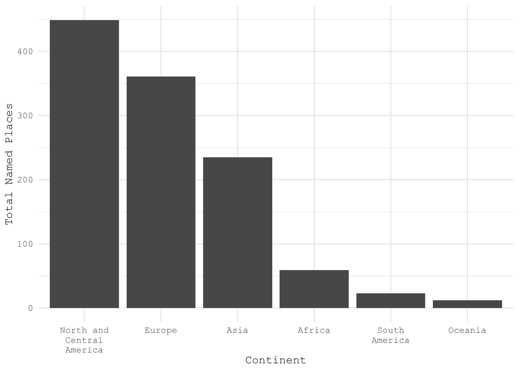

```r
cont_plot <- ggplot(cont_counts) +
  geom_col(aes(x = fct_rev(fct_reorder(place, total)),
               y = total)) +
  theme_minimal() +
  scale_x_discrete(labels = label_wrap(width = 12)) +
  xlab("Continent") +
  ylab("Total Named Places") +
  theme(text = element_text(family = "Courier New"))

cont_plot
```

I want to do a graph that colors each country according to its continent, but I need to join continent values in to the country counts dataframe to do this.

```r
country_cont_pair <- full_place_data %>%
  select(place, place_type, parent_hierarchy, parent_type) %>%
  filter(place_type %in% country_types == T &
           parent_type %in% cont_types) %>%
  distinct(place, parent_hierarchy) %>%
  mutate(country = place) %>%
  mutate(continent = parent_hierarchy) %>%
  select(country, continent)

parent_hierarchies_sep <- full_place_data %>%
  select(place_ID, parent_hierarchy, parent_type)

# ok this is super wrong, gotta fix this
# pseuocode:
# for every row in the df:
# 1. grab the place ID
# 2. take the country for that ID and put it in the country column (might be from place or parent)
# 3. take the continent for that ID and put it in the continent column (there are no continents named in questions)

df <- full_place_data %>%
  filter(place_type != "") # this is too long of a variable name to keep writing out!!
cc <- as.data.frame(matrix(ncol = 2, nrow = nrow(df)))
colnames(cc) <- c("country", "continent")
for(i in 1:nrow(df)){
  ID <- df$place_ID[i]
  # work through *place* column to find countries
  for(j in 1:nrow(df)){
    if(df$place_ID[j] == ID & df$place_type[j] == "primary political entities"){
      cc$country[i] <- df$place[j]
      cc$continent[i] <- df$parent_hierarchy[j]
    } else if(df$place_ID[j] == ID & df$place_type[j] == "former primary political entities" & df$parent_type[j] == "continent") {
      cc$country[i] <- df$place[j]
      cc$continent[i] <- df$parent_hierarchy[j]
    }
  }
  # work through *parent_hierarchy* column to find countries
  for(k in 1:nrow(df)){
    if(df$place_ID[k] == ID & df$parent_type[k] == "primary political entities" |
       df$place_ID[k] == ID & df$parent_type[k] == "former primary political entities"){
      cc$country[i] <- df$parent_hierarchy[k]
    if(df$parent_type[k+1] == "continent"){
      cc$continent[i] <- df$parent_hierarchy[k+1]
    } else if (df$parent_type[k+1] != "continent"){
        ""
      }
    }
  }
  # manually fix some errors/NAs
 if(df$place[i] == "Holy Roman Empire" |
    df$parent_hierarchy[i] == "Holy Roman Empire"){
   cc$country[i] <- "Holy Roman Empire"
   cc$continent[i] <- "Europe"
 } else if(df$place[i] == "Soviet Union" |
    df$parent_hierarchy[i] == "Soviet Union"){
   cc$country[i] <- "Soviet Union"
   cc$continent[i] <- "Asia"
} else if(df$place[i] == "German Empire" |
    df$parent_hierarchy[i] == "German Empire"){
  cc$country[i] <- "Germann Empire"
  cc$continent[i] <- "Europe"
} else if(df$place[i] == "Prussia" |
    df$parent_hierarchy[i] == "Prussia"){
  cc$country[i] <- "Prussia"
  cc$continent[i] <- "Europe"
} else if(df$place[i] == "Czech Republic" |
    df$parent_hierarchy[i] == "Czech Republic"){
  cc$country[i] <- "Czech Republic"
  cc$continent[i] <- "Europe"
} else if(df$place[i] == "Saudi Arabia" |
    df$parent_hierarchy[i] == "Saudi Arabia"){
  cc$country[i] <- "Saudi Arabia"
  cc$continent[i] <- "Asia"
} else if(df$place[i] == "Switzerland" |
    df$parent_hierarchy[i] == "Switzerland"){
  cc$country[i] <- "Switzerland"
  cc$continent[i] <- "Europe"
} else if(df$place[i] == "Syria" |
    df$parent_hierarchy[i] == "Syria"){
  cc$country[i] <- "Syria"
  cc$continent[i] <- "Asia"
} else if(df$place[i] == "Hapsburg Empire" |
    df$parent_hierarchy[i] == "Hapsburg Empire"){
  cc$country[i] <- "Hapsburg Empire"
  cc$continent[i] <- "Europe"
} else if(df$place[i] == "Lydia" |
    df$parent_hierarchy[i] == "Lydia"){
  cc$country[i] <- "Lydia"
  cc$continent[i] <- "Asia"
} else if(df$place[i] == "Kenya" |
    df$parent_hierarchy[i] == "Kenya"){
  cc$country[i] <- "Kenya"
  cc$continent[i] <- "Africa"
} else if(df$place[i] == "Roman Empire" |
    df$parent_hierarchy[i] == "Roman Empire"){
  cc$country[i] <- "Roman Empire"
  cc$continent[i] <- "Europe"
} else if(df$place[i] == "Tunisia" |
    df$parent_hierarchy[i] == "Tunisia"){
  cc$country[i] <- "Tunisia"
  cc$continent[i] <- "Africa"
} else if(df$place[i] == "Uzbekistan" |
    df$parent_hierarchy[i] == "Uzbekistan"){
  cc$country[i] <- "Uzbekistan"
  cc$continent[i] <- "Asia"
} else if(df$place[i] == "Austria-Hungary" |
    df$parent_hierarchy[i] == "Austria-Hungary"){
  cc$country[i] <- "Austria-Hungary"
  cc$continent[i] <- "Europe"
} else if(df$place[i] == "Aztec Empire" |
    df$parent_hierarchy[i] == "Aztec Empire"){
  cc$country[i] <- "Aztec Empire"
  cc$continent[i] <- "South America"
} else if(df$place[i] == "Bithynia" |
    df$parent_hierarchy[i] == "Bithynia"){
  cc$country[i] <- "Bithynia"
  cc$continent[i] <- "Asia"
} else if(df$place[i] == "German Democratic Republic" |
    df$parent_hierarchy[i] == "German Democratic Republic"){
  cc$country[i] <- "German Democratic Republic"
  cc$continent[i] <- "Europe"
} else if(df$place[i] == "Khmer (Empire)" |
    df$parent_hierarchy[i] == "Khmer (Empire)"){
  cc$country[i] <- "Khmer (Empire)"
  cc$continent[i] <- "Asia"
} else if(df$place[i] == "Korea" |
    df$parent_hierarchy[i] == "Korea"){
  cc$country[i] <- "Korea"
  cc$continent[i] <- "Asia"
} else if(df$place[i] == "Mali Empire" |
    df$parent_hierarchy[i] == "Mali Empire"){
  cc$country[i] <- "Mali Empire"
  cc$continent[i] <- "Africa"
} else if(df$place[i] == "Matapa" |
    df$parent_hierarchy[i] == "Matapa"){
  cc$country[i] <- "Matapa"
  cc$continent[i] <- "Africa"
} else if(df$place[i] == "Numidia" |
    df$parent_hierarchy[i] == "Numidia"){
  cc$country[i] <- "Numidia"
  cc$continent[i] <- "Africa"
} else if(df$place[i] == "Republic of China" |
    df$parent_hierarchy[i] == "Republic of China"){
  cc$country[i] <- "Republic of China"
  cc$continent[i] <- "Asia"
} else if(df$place[i] == "West Germany" |
    df$parent_hierarchy[i] == "West Germany"){
  cc$country[i] <- "West Germany"
  cc$continent[i] <- "Europe"
} else if(df$place[i] == "Yugoslavia" |
    df$parent_hierarchy[i] == "Yugoslavia"){
  cc$country[i] <- "Yugoslavia"
  cc$continent[i] <- "Europe"
} else if(df$place[i] == "Afghanistan" |
    df$parent_hierarchy[i] == "Afghanistan"){
  cc$country[i] <- "Afghanistan"
  cc$continent[i] <- "Asia"
} else if(df$place[i] == "Belarus" |
    df$parent_hierarchy[i] == "Belarus"){
  cc$country[i] <- "Belarus"
  cc$continent[i] <- "Europe"
} else if(df$place[i] == "China (historical)" |
    df$parent_hierarchy[i] == "China (historical)"){
  cc$country[i] <- "China (historical)"
  cc$continent[i] <- "Asia"
} else if(df$place[i] == "Côte d'Ivoire" |
    df$parent_hierarchy[i] == "Côte d'Ivoire"){
  cc$country[i] <- "Côte d'Ivoire"
  cc$continent[i] <- "Africa"
} else if(df$place[i] == "Malaysia" |
    df$parent_hierarchy[i] == "Malaysia"){
  cc$country[i] <- "Malaysia"
  cc$continent[i] <- "Asia"
} else if(df$place[i] == "Slovakia" |
    df$parent_hierarchy[i] == "Slovakia"){
  cc$country[i] <- "Slovakia"
  cc$continent[i] <- "Europe"
} else if(df$place[i] == "South Georgia and South Sandwich Islands" |
    df$parent_hierarchy[i] == "South Georgia and South Sandwich Islands"){
  cc$country[i] <- "South Georgia and South Sandwich Islands"
  cc$continent[i] <- "South America"
} else if(df$place[i] == "Tajikistan" |
    df$parent_hierarchy[i] == "Tajikistan"){
  cc$country[i] <- "Tajikistan"
  cc$continent[i] <- "Asia"
} else if(df$place[i] == "Western Sahara" |
    df$parent_hierarchy[i] == "Western Sahara"){
  cc$country[i] <- "Western Sahara"
  cc$continent[i] <- "Africa"
}
}

# remove duplicates
cc <- cc %>%
  distinct(country, continent) %>%
  filter(is.na(continent) == FALSE)

country_cont_counts <- as.data.frame(left_join(country_counts, cc, by = c("place" = "country"))) %>%
  arrange(desc(total))

# manually add continents for German Empire, Austria-Hungary, China (historical)
country_cont_counts$continent[34] <- "Europe"
country_cont_counts$continent[82] <- "Europe"
country_cont_counts$continent[123] <- "Asia"

continent_counts <- country_cont_counts %>%
  group_by(continent) %>%
  summarize(total = sum(total)) %>%
  mutate(proportion = total/sum(country_cont_counts$total))
```

# Plot frequencies of countries, colored by continent

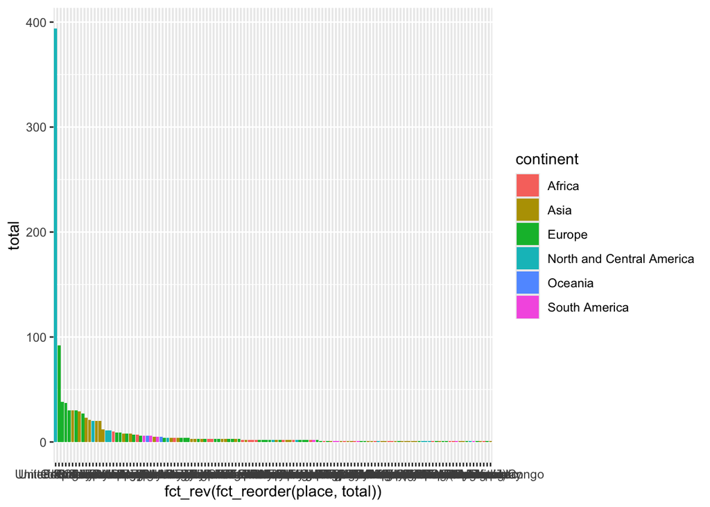

```r
ggplot(country_cont_counts) +
  geom_col(aes(x = fct_rev(fct_reorder(place, total)),
               y = total,
               fill = continent))
```

There’s a bit too much information happening all at once in this visualization, but it’s interesting to see the distribution of questions by country/continent. That tall bar is the U.S.

# Isolating questions that mention women for use in AntConc

I have one folder that contains text files for every question and answer in the set. However, I want to be able to use AntConc to compare questions that mention women, questions that have women as the answer line, and questions that ignore women. So, I need a folder of text files for each of these categories. I’ll use the same for-loop as I did to write the text files originally, but use `if` statements to restrict which questions are written to files.

```r
# This code doesn't need to be run! The `corpora` directory contains folders with all of the questions that mention a woman (folder = woman_named_txt), have a woman answer ((folder = woman_answer_txt)), do not mention women at all (folder = woman_ignored_txt)

# If you really want to run this giant block, just un-comment the rest of the block.

# woman_mentioned <- woman_named_df$ID
# woman_topic <- woman_qs$ID
#
# nhbb_fresh <- nhbb_clean
#
#
# for(i in 1:nrow(nhbb_fresh)){
#   if(nhbb_fresh$ID[i] %in% woman_mentioned == T){
#       q_filepath <- paste("woman_named_txt/", nhbb_fresh$ID[i], "_q.txt", sep = "")
#       nhbb_fresh$q_file[i] <- q_filepath
#       a_filepath <- paste("woman_named_txt/", nhbb_fresh$ID[i], "_a.txt", sep = "")
#       nhbb_fresh$a_file[i] <- a_filepath
#       writeLines(nhbb_fresh$q_text[i], q_filepath)
#       writeLines(nhbb_fresh$a_text[i], a_filepath)
#   # write additional files for bonus questions + answers
#     if(nhbb_fresh$bonus_q_text[i] != ""){
#       bonus_q_filepath <- paste("woman_named_txt/", nhbb_fresh$ID[i], "_bonus_q.txt", sep = "")
#       nhbb_fresh$bonus_q_file[i] <- bonus_q_filepath
#       bonus_a_filepath <- paste("woman_named_txt/", nhbb_fresh$ID[i], "_bonus_a.txt", sep = "")
#       nhbb_fresh$bonus_a_file[i] <- bonus_a_filepath
#       writeLines(nhbb_fresh$bonus_q_text[i], bonus_q_filepath)
#       writeLines(nhbb_fresh$bonus_a_text[i], bonus_a_filepath)
#     } else if(nhbb_fresh$bonus_q_text[i] == ""){
#       nhbb_fresh$bonus_q_file[i] <- NA
#       nhbb_fresh$bonus_a_file[i] <- NA
#     }
#   }
# }

# for(i in 1:nrow(nhbb_fresh)){
#   if(nhbb_fresh$ID[i] %in% woman_topic == T){
#      q_filepath <- paste("woman_answer_txt/", nhbb_fresh$ID[i], "_q.txt", sep = "")
#       nhbb_fresh$q_file[i] <- q_filepath
#       a_filepath <- paste("woman_answer_txt/", nhbb_fresh$ID[i], "_a.txt", sep = "")
#       nhbb_fresh$a_file[i] <- a_filepath
#       writeLines(nhbb_fresh$q_text[i], q_filepath)
#       writeLines(nhbb_fresh$a_text[i], a_filepath)
#   # write additional files for bonus questions + answers
#     if(nhbb_fresh$bonus_q_text[i] != ""){
#       bonus_q_filepath <- paste("woman_answer_txt/", nhbb_fresh$ID[i], "_bonus_q.txt", sep = "")
#       nhbb_fresh$bonus_q_file[i] <- bonus_q_filepath
#       bonus_a_filepath <- paste("woman_answer_txt/", nhbb_fresh$ID[i], "_bonus_a.txt", sep = "")
#       nhbb_fresh$bonus_a_file[i] <- bonus_a_filepath
#       writeLines(nhbb_fresh$bonus_q_text[i], bonus_q_filepath)
#       writeLines(nhbb_fresh$bonus_a_text[i], bonus_a_filepath)
#     } else if(nhbb_fresh$bonus_q_text[i] == ""){
#       nhbb_fresh$bonus_q_file[i] <- NA
#       nhbb_fresh$bonus_a_file[i] <- NA
#     }
#   } else if(nhbb_fresh$ID[i] %in% woman_topic == F & nhbb_fresh$ID[i] %in% woman_mentioned == F){
#       q_filepath <- paste("women_ignored_txt/", nhbb_fresh$ID[i], "_q.txt", sep = "")
#       nhbb_fresh$q_file[i] <- q_filepath
#       a_filepath <- paste("women_ignored_txt/", nhbb_fresh$ID[i], "_a.txt", sep = "")
#       nhbb_fresh$a_file[i] <- a_filepath
#       writeLines(nhbb_fresh$q_text[i], q_filepath)
#       writeLines(nhbb_fresh$a_text[i], a_filepath)
#   # write additional files for bonus questions + answers
#     if(nhbb_fresh$bonus_q_text[i] != ""){
#       bonus_q_filepath <- paste("women_ignored_txt/", nhbb_fresh$ID[i], "_bonus_q.txt", sep = "")
#       nhbb_fresh$bonus_q_file[i] <- bonus_q_filepath
#       bonus_a_filepath <- paste("women_ignored_txt/", nhbb_fresh$ID[i], "_bonus_a.txt", sep = "")
#       nhbb_fresh$bonus_a_file[i] <- bonus_a_filepath
#       writeLines(nhbb_fresh$bonus_q_text[i], bonus_q_filepath)
#       writeLines(nhbb_fresh$bonus_a_text[i], bonus_a_filepath)
#     } else if(nhbb_fresh$bonus_q_text[i] == ""){
#       nhbb_fresh$bonus_q_file[i] <- NA
#       nhbb_fresh$bonus_a_file[i] <- NA
#     }
#   }
# }
```

# Use SpaCy to select questions with PEOPLE as the answer

I ought to compare questions for which a woman is the answer to questions for which a non-woman **person** is the answer. I will do this by using SpaCy’s NER function to identify which answers are people.

```python
# process text into doc format
nhbb_spacy = nhbb_spacy.fillna("")
nhbb_spacy['a_text_doc'] = nhbb_spacy['a_text'].apply(process_text)
nhbb_spacy['bonus_a_text_doc'] = nhbb_spacy['bonus_a_text'].apply(process_text)
nhbb_spacy['bonus_q_text_doc'] = nhbb_spacy['bonus_q_text'].apply(process_text)
# Apply function to q_text_doc column and store named entity tags in new column
nhbb_spacy["ne_tags_a"] = nhbb_spacy["a_text_doc"].apply(extract_ne_tags)
nhbb_spacy["ne_tags_bonus_a"] = nhbb_spacy["bonus_a_text_doc"].apply(extract_ne_tags)
```

```r
nhbb_spacyr_a <- py_to_r(py$nhbb_spacy)

person_answers <- nhbb_spacyr_a %>%
  filter(ne_tags_a == "PERSON" | ne_tags_bonus_a == "PERSON")

person_IDs <- person_answers$ID
```

This method isn’t flawless, but with a set this large it is more time-efficient than manually identifying every question with a person as the answer.

I’ll now write these questions and answers to text files, like I did before.

For the record, I am including the full question and associated bonus questions, because bonus questions are meant to be on the same topic as the tossup.

```r
# Like for the block named `category-txt-files` you don't need to run this one -- the `corpora` directory contains the folder `people-answers`
# ALSO, I didn't even end up using this method to generate that corpus! You'll see shortly that I manually added metadata to identify which questions had people as the answers.

# nhbb_people <- nhbb_clean %>%
#   filter(ID %in% people_answers$ID == T)
#
# # write txt files
# for (j in 1:nrow(nhbb_people)) {
#   q_filepath <- paste("people_answers/all/", nhbb_people$ID[j], "_q.txt", sep = "")
#   nhbb_people$q_file[j] <- q_filepath
#   a_filepath <- paste("people_answers/all/", nhbb_people$ID[j], "_a.txt", sep = "")
#   nhbb_people$a_file[j] <- a_filepath
#   writeLines(nhbb_people$q_text[j], q_filepath)
#   writeLines(nhbb_people$a_text[j], a_filepath)
#   # write additional files for bonus questions + answers
#   if(nhbb_people$bonus_q_text[j] != ""){
#     bonus_q_filepath <- paste("people_answers/all/", nhbb_people$ID[j], "_bonus_q.txt", sep = "")
#     nhbb_people$bonus_q_file[j] <- bonus_q_filepath
#     bonus_a_filepath <- paste("people_answers/all/", nhbb_people$ID[j], "_bonus_a.txt", sep = "")
#     nhbb_people$bonus_a_file[j] <- bonus_a_filepath
#     writeLines(nhbb_people$bonus_q_text[j], bonus_q_filepath)
#     writeLines(nhbb_people$bonus_a_text[j], bonus_a_filepath)
#   } else{
#     nhbb_people$bonus_q_file[j] <- NA
#     nhbb_people$bonus_a_file[j] <- NA
#   }
# }
#
# # now write txt files in separate folders for women and men
# for(i in 1:nrow(nhbb_people)){
#   if(nhbb_people$ID[i] %in% woman_topic == F){
#       q_filepath <- paste("people_answers/men/", nhbb_people$ID[i], "_q.txt", sep = "")
#       nhbb_people$q_file[i] <- q_filepath
#       a_filepath <- paste("people_answers/men/", nhbb_people$ID[i], "_a.txt", sep = "")
#       nhbb_people$a_file[i] <- a_filepath
#       writeLines(nhbb_people$q_text[i], q_filepath)
#       writeLines(nhbb_people$a_text[i], a_filepath)
#   # write additional files for bonus questions + answers
#     if(nhbb_people$bonus_q_text[i] != ""){
#       bonus_q_filepath <- paste("people_answers/men/", nhbb_people$ID[i], "_bonus_q.txt", sep = "")
#       nhbb_people$bonus_q_file[i] <- bonus_q_filepath
#       bonus_a_filepath <- paste("people_answers/men/", nhbb_people$ID[i], "_bonus_a.txt", sep = "")
#       nhbb_people$bonus_a_file[i] <- bonus_a_filepath
#       writeLines(nhbb_people$bonus_q_text[i], bonus_q_filepath)
#       writeLines(nhbb_people$bonus_a_text[i], bonus_a_filepath)
#     } else if(nhbb_people$bonus_q_text[i] == ""){
#       nhbb_people$bonus_q_file[i] <- NA
#       nhbb_people$bonus_a_file[i] <- NA
#     }
#   }
#   else if(nhbb_people$ID[i] %in% woman_topic == T){
#       q_filepath <- paste("people_answers/women/", nhbb_people$ID[i], "_q.txt", sep = "")
#       nhbb_people$q_file[i] <- q_filepath
#       a_filepath <- paste("people_answers/women/", nhbb_people$ID[i], "_a.txt", sep = "")
#       nhbb_people$a_file[i] <- a_filepath
#       writeLines(nhbb_people$q_text[i], q_filepath)
#       writeLines(nhbb_people$a_text[i], a_filepath)
#   # write additional files for bonus questions + answers
#     if(nhbb_people$bonus_q_text[i] != ""){
#       bonus_q_filepath <- paste("people_answers/women/", nhbb_people$ID[i], "_bonus_q.txt", sep = "")
#       nhbb_people$bonus_q_file[i] <- bonus_q_filepath
#       bonus_a_filepath <- paste("people_answers/women/", nhbb_people$ID[i], "_bonus_a.txt", sep = "")
#       nhbb_people$bonus_a_file[i] <- bonus_a_filepath
#       writeLines(nhbb_people$bonus_q_text[i], bonus_q_filepath)
#       writeLines(nhbb_people$bonus_a_text[i], bonus_a_filepath)
#     } else if(nhbb_people$bonus_q_text[i] == ""){
#       nhbb_people$bonus_q_file[i] <- NA
#       nhbb_people$bonus_a_file[i] <- NA
#     }
#   }
# }
```

```r
# This block only works if you run all of the above blocks

# nhbb_people_counts <- nhbb_people %>%
#   select(ID, a_text, bonus_a_text) %>%
#   group_by(a_text) %>%
#   count()
```

# Use SpaCy to pick out all people named in questions

```python
# Define function to extract words tagged as "PERSON"
def extract_people(doc):
  return[ent.text for ent in doc.ents if ent.label_ == "PERSON"]

# Apply function to nhbb_spacy DF column "q_text_doc" and save in new column
nhbb_spacy["people"] = nhbb_spacy["q_text_doc"].apply(extract_people)
nhbb_spacy["bonus_people"] = nhbb_spacy["bonus_q_text_doc"].apply(extract_people)
```

```r
# only dealing with tossups for now --> bonuses are likely to repeat the same people anyways
people <- py_to_r(py$nhbb_spacy) %>%
  select(people) %>%
  mutate(people = as.vector(people))

# reusing code from the proper nouns experiment
for (i in 1:nrow(people)){
  people$people[i] <- str_remove_all(people$people[i], pattern = "c\\(")
  people$people[i] <- str_remove_all(people$people[i], pattern = "\\)")
  people$people[i] <- str_remove_all(people$people[i], pattern = "\"")
  people$people[i] <- str_remove_all(people$people[i], pattern = "list\\(")
  people$people[i] <- str_remove_all(people$people[i], pattern = "’s")
  people$people[i] <- str_remove_all(people$people[i], pattern = "^a")
  people$people[i] <- str_trim(people$people[i])
}

people_q_count <- people %>%
  filter(people != "") %>%
  separate_longer_delim(cols = people, delim = ", ") %>%
  group_by(people) %>%
  count() %>%
  arrange(desc(n))

head(people_q_count)
```

| people | n |
| --- | --- |
| Jesus | 7 |
| Alexander Hamilton | 6 |
| George Washington | 6 |
| Jackson | 6 |
| Richard Nixon | 6 |
| Abraham Lincoln | 5 |

```r
# I should also count the people who are answers!

for (i in 1:nrow(person_answers)){
  person_answers$a_text[i] <- str_trim(person_answers$a_text[i])
}

person_answers_count <- person_answers %>%
  group_by(a_text) %>%
  count() %>%
  arrange(desc(n))

# and I'm going to manually add the women too

women_q_counts <- woman_named_df %>%
  filter(names != "") %>%
  separate_longer_delim(cols = names, delim = ", ") %>%
  group_by(names) %>%
  count() %>%
  arrange(desc(n))

women_a_counts <- woman_qs %>%
  filter(answer != "") %>%
  separate_longer_delim(cols = answer, delim = ", ") %>%
  group_by(answer) %>%
  count() %>%
  arrange(desc(n))

women_counts_total <- full_join(women_q_counts, women_a_counts, by = c("names" = "answer")) %>%
  replace(is.na(.), 0) %>%
  mutate(n.total = rowSums(across(where(is.numeric)))) %>%
  select(names, n.total) %>%
  arrange(desc(n.total))

## ABANDONING METHOD BECAUSE IT DIDN'T REALLY WORK -- SpaCy missed a lot of people.
```

This really didn’t work very well - reading through the questions, a lot of people were missed.

# Re-analyzing the people answers

The SpaCy approach to identifying questions with people as the answers was not super accurate – lots of questions about people were not identified, and questions where the answer was not a person WERE identified as people. So, I hand-tagged all the questions for whether the answer is a person, and if that person is a mythological/religious figure.

```r
nhbb_people_answers <- nhbb_clean %>%
  filter(is_person_a == TRUE | is_person_b == TRUE)
```

```r
people_answers_tossups <- as.data.frame(matrix(ncol = 5, nrow = nrow(nhbb_people_answers)))
colnames(people_answers_tossups) <- c("ID", "answer", "type", "is_myth", "is_woman")

people_answers_bonus <- as.data.frame(matrix(ncol = 5, nrow = nrow(nhbb_people_answers)))
colnames(people_answers_bonus) <- c("ID", "answer", "type", "is_myth", "is_woman")

for(i in 1:nrow(nhbb_people_answers)){
 if(nhbb_people_answers$is_person_a[i] == T){
   people_answers_tossups$ID[i] <- nhbb_people_answers$ID[i]
   people_answers_tossups$answer[i] <- nhbb_people_answers$a_text[i]
   people_answers_tossups$type[i] <- "tossup"
   people_answers_tossups$is_myth[i] <- nhbb_people_answers$is_myth_a[i]
   people_answers_tossups$is_woman[i] <- nhbb_people_answers$is_answer[i]
 }
}

for(i in 1:nrow(nhbb_people_answers)){
 if(nhbb_people_answers$is_person_b[i] == T){
   people_answers_bonus$ID[i] <- nhbb_people_answers$ID[i]
   people_answers_bonus$answer[i] <- nhbb_people_answers$bonus_a_text[i]
   people_answers_bonus$type[i] <- "bonus"
   people_answers_bonus$is_myth[i] <- nhbb_people_answers$is_myth_b[i]
   people_answers_bonus$is_woman[i] <-  nhbb_people_answers$is_answer[i]
 }
}

people_answers <- rbind(people_answers_tossups, people_answers_bonus) %>%
  filter(is.na(ID) == F)

# whoops some questions are accidentally coded as woman answers

for(i in 1:nrow(people_answers)){
  if(people_answers$answer[i] %in% women_counts_total$names == TRUE |
     people_answers$answer[i] == "Sappho"){
    people_answers$is_woman[i] <- TRUE
  } else{
    people_answers$is_woman[i] <- FALSE
  }
}
```

```r
people_answer_count <- people_answers %>%
  group_by(answer) %>%
  summarize(total = n()) %>%
  arrange(desc(total))
```

```r
all_people_count <- full_join(people_q_count, people_answer_count, by = c("people" = "answer")) %>%
  replace(is.na(.), 0) %>%
  mutate(n.total = rowSums(across(where(is.numeric)))) %>%
  select(people, n.total) %>%
  arrange(desc(n.total))
```

# Chi-Square test of male myth vs female myth proportions

```r
chisq_myth <- as.data.frame(matrix(ncol = 2, nrow = 2))
rownames(chisq_myth) <- c("myth", "non_myth")
colnames(chisq_myth) <- c("women", "non_women")

chisq_myth$women[1] <- nrow(people_answers %>% filter(is_myth == T & is_woman == T))
chisq_myth$women[2] <- nrow(people_answers %>% filter(is_myth == F & is_woman == T))
chisq_myth$non_women[1] <- nrow(people_answers %>% filter(is_myth == T & is_woman == F))
chisq_myth$non_women[2] <- nrow(people_answers %>% filter(is_myth == F & is_woman == F))

chisq.test(chisq_myth)
```

```
##
##  Pearson's Chi-squared test with Yates' continuity correction
##
## data:  chisq_myth
## X-squared = 16.065, df = 1, p-value = 6.121e-05
```

# More geographic analysis

## How many unique places are named per continent?

```r
north_am <- full_place_data %>%
  filter(parent_type == "continents" & parent_hierarchy == "North and Central America")

north_am_unique <- north_am %>%
  distinct(place)

europe <- full_place_data %>%
  filter(parent_type == "continents" & parent_hierarchy == "Europe")

europe_unique <- europe %>%
  distinct(place)

asia <- full_place_data %>%
  filter(parent_type == "continents" & parent_hierarchy == "Asia")

asia_unique <- asia %>%
  distinct(place)

africa <- full_place_data %>%
  filter(parent_type == "continents" & parent_hierarchy == "Africa")

africa_unique <- africa %>%
  distinct(place)

south_am <- full_place_data %>%
  filter(parent_type == "continents" & parent_hierarchy == "South America")

south_am_unique <- south_am %>%
  distinct(place)

oceania <- full_place_data %>%
  filter(parent_type == "continents" & parent_hierarchy == "Oceania")

oceania_unique <- oceania %>%
  distinct(place)

unique_place_counts <- as.data.frame(matrix(nrow = 6, ncol = 2))
colnames(unique_place_counts) <- c("continent", "n_unique")

unique_place_counts$continent <- c("North and Central America", "Europe", "Asia", "Africa", "South America", "Oceania")

unique_place_counts$n_unique <- c(nrow(north_am_unique), nrow(europe_unique), nrow(asia_unique), nrow(africa_unique),nrow(south_am_unique), nrow(oceania_unique))

unique_place_counts <- unique_place_counts %>%
  left_join(cont_counts, by = c("continent" = "place"))

unique_place_counts
```

| continent | n_unique | total |
| --- | --- | --- |
| North and Central America | 147 | 449 |
| Europe | 140 | 361 |
| Asia | 116 | 235 |
| Africa | 40 | 59 |
| South America | 14 | 23 |
| Oceania | 6 | 12 |

## Write questions mentioning places in each continent to separate folders for AntConc

```r
# this is also already available under the corpora directory
# the folder `continents` contains a folder for **each** continent

# un-comment this block if you want to run it!

# africa_qs <- nhbb_clean %>%
#   filter(ID %in% africa$ID == T)
#
# write_txt(africa_qs, "corpora/continents/africa/")
#
# south_am_qs <- nhbb_clean %>%
#   filter(ID %in% south_am$ID == T)
#
# write_txt(south_am_qs, "corpora/continents/south_am/")
#
# oceania_qs <- nhbb_clean %>%
#   filter(ID %in% oceania$ID == T)
#
# write_txt(oceania_qs, "corpora/continents/oceania/")
#
# europe_qs <- nhbb_clean %>%
#   filter(ID %in% europe$ID == T)
#
# write_txt(europe_qs, "corpora/continents/europe/")
#
# asia_qs <- nhbb_clean %>%
#   filter(ID %in% asia$ID == T)
#
# write_txt(asia_qs, "corpora/continents/asia/")
#
# north_am_qs <- nhbb_clean %>%
#   filter(ID %in% north_am$ID == T)
#
# write_txt(north_am_qs, "corpora/continents/north_am/")
```

# That’s all, folks!

```r
library(report)
cite_packages()
```

```
##   - Bache S, Wickham H (2022). _magrittr: A Forward-Pipe Operator for R_. R package version 2.0.3, <https://CRAN.R-project.org/package=magrittr>.
##   - Cambon J, Hernangómez D, Belanger C, Possenriede D (2021). "tidygeocoder: An R package for geocoding." _Journal of Open Source Software_, *6*(65), 3544. doi:10.21105/joss.03544 <https://doi.org/10.21105/joss.03544>, R package version 1.0.5, <https://doi.org/10.21105/joss.03544>.
##   - Chang W (2023). _extrafont: Tools for Using Fonts_. R package version 0.19, <https://CRAN.R-project.org/package=extrafont>.
##   - Cheng J, Schloerke B, Karambelkar B, Xie Y (2024). _leaflet: Create Interactive Web Maps with the JavaScript 'Leaflet' Library_. R package version 2.2.2, <https://CRAN.R-project.org/package=leaflet>.
##   - Grolemund G, Wickham H (2011). "Dates and Times Made Easy with lubridate." _Journal of Statistical Software_, *40*(3), 1-25. <https://www.jstatsoft.org/v40/i03/>.
##   - Makowski D, Lüdecke D, Patil I, Thériault R, Ben-Shachar M, Wiernik B (2023). "Automated Results Reporting as a Practical Tool to Improve Reproducibility and Methodological Best Practices Adoption." _CRAN_. <https://easystats.github.io/report/>.
##   - Müller K, Wickham H (2023). _tibble: Simple Data Frames_. R package version 3.2.1, <https://CRAN.R-project.org/package=tibble>.
##   - R Core Team (2024). _R: A Language and Environment for Statistical Computing_. R Foundation for Statistical Computing, Vienna, Austria. <https://www.R-project.org/>.
##   - Schwalb-Willmann J (2024). _basemaps: Accessing Spatial Basemaps in R_. R package version 0.0.8, <https://CRAN.R-project.org/package=basemaps>.
##   - Ushey K, Allaire J, Tang Y (2024). _reticulate: Interface to 'Python'_. R package version 1.40.0, <https://CRAN.R-project.org/package=reticulate>.
##   - Wickham H (2016). _ggplot2: Elegant Graphics for Data Analysis_. Springer-Verlag New York. ISBN 978-3-319-24277-4, <https://ggplot2.tidyverse.org>.
##   - Wickham H (2023). _forcats: Tools for Working with Categorical Variables (Factors)_. R package version 1.0.0, <https://CRAN.R-project.org/package=forcats>.
##   - Wickham H (2023). _stringr: Simple, Consistent Wrappers for Common String Operations_. R package version 1.5.1, <https://CRAN.R-project.org/package=stringr>.
##   - Wickham H, Averick M, Bryan J, Chang W, McGowan LD, François R, Grolemund G, Hayes A, Henry L, Hester J, Kuhn M, Pedersen TL, Miller E, Bache SM, Müller K, Ooms J, Robinson D, Seidel DP, Spinu V, Takahashi K, Vaughan D, Wilke C, Woo K, Yutani H (2019). "Welcome to the tidyverse." _Journal of …
##   - Wickham H, François R, Henry L, Müller K, Vaughan D (2023). _dplyr: A Grammar of Data Manipulation_. R package version 1.1.4, <https://CRAN.R-project.org/package=dplyr>.
##   - Wickham H, Henry L (2023). _purrr: Functional Programming Tools_. R package version 1.0.2, <https://CRAN.R-project.org/package=purrr>.
##   - Wickham H, Hester J, Bryan J (2024). _readr: Read Rectangular Text Data_. R package version 2.1.5, <https://CRAN.R-project.org/package=readr>.
##   - Wickham H, Pedersen T, Seidel D (2023). _scales: Scale Functions for Visualization_. R package version 1.3.0, <https://CRAN.R-project.org/package=scales>.
##   - Wickham H, Vaughan D, Girlich M (2024). _tidyr: Tidy Messy Data_. R package version 1.3.1, <https://CRAN.R-project.org/package=tidyr>.
##   - Xie Y (2024). _knitr: A General-Purpose Package for Dynamic Report Generation in R_. R package version 1.49, <https://yihui.org/knitr/>. Xie Y (2015). _Dynamic Documents with R and knitr_, 2nd edition. Chapman and Hall/CRC, Boca Raton, Florida. ISBN 978-1498716963, <https://yihui.org/knitr/>.…
##   - Zhu H (2024). _kableExtra: Construct Complex Table with 'kable' and Pipe Syntax_. R package version 1.4.0, <https://CRAN.R-project.org/package=kableExtra>.
```